# Risk Factor Analysis

## Outcome Variable

**Outcome Variable:** stunted

## Predictor Variables

**Intervention Variable:** tr

**Adjustment Set:**

unadjusted

## Stratifying Variables

The analysis was stratified on these variable(s):

- nchldlt5
- agecat
- studyid
- country

## Data Summary

| nchldlt5 | agecat | studyid | country | tr | stunted | n_cell | n |
| --- | --- | --- | --- | --- | --- | --- | --- |
| 1 | 24 months | ki1000107-Serrinha-VitA | BRAZIL | Control | 0 | 17 | 50 |
| 1 | 24 months | ki1000107-Serrinha-VitA | BRAZIL | Control | 1 | 11 | 50 |
| 1 | 24 months | ki1000107-Serrinha-VitA | BRAZIL | VitA | 0 | 17 | 50 |
| 1 | 24 months | ki1000107-Serrinha-VitA | BRAZIL | VitA | 1 | 5 | 50 |
| 3+ | 24 months | ki1000107-Serrinha-VitA | BRAZIL | Control | 0 | 8 | 29 |
| 3+ | 24 months | ki1000107-Serrinha-VitA | BRAZIL | Control | 1 | 10 | 29 |
| 3+ | 24 months | ki1000107-Serrinha-VitA | BRAZIL | VitA | 0 | 6 | 29 |
| 3+ | 24 months | ki1000107-Serrinha-VitA | BRAZIL | VitA | 1 | 5 | 29 |
| 2 | 24 months | ki1000107-Serrinha-VitA | BRAZIL | Control | 0 | 14 | 51 |
| 2 | 24 months | ki1000107-Serrinha-VitA | BRAZIL | Control | 1 | 10 | 51 |
| 2 | 24 months | ki1000107-Serrinha-VitA | BRAZIL | VitA | 0 | 11 | 51 |
| 2 | 24 months | ki1000107-Serrinha-VitA | BRAZIL | VitA | 1 | 16 | 51 |
| 3+ | 6 months | ki1000107-Serrinha-VitA | BRAZIL | Control | 0 | 0 | 6 |
| 3+ | 6 months | ki1000107-Serrinha-VitA | BRAZIL | Control | 1 | 2 | 6 |
| 3+ | 6 months | ki1000107-Serrinha-VitA | BRAZIL | VitA | 0 | 3 | 6 |
| 3+ | 6 months | ki1000107-Serrinha-VitA | BRAZIL | VitA | 1 | 1 | 6 |
| 1 | 6 months | ki1000107-Serrinha-VitA | BRAZIL | Control | 0 | 6 | 16 |
| 1 | 6 months | ki1000107-Serrinha-VitA | BRAZIL | Control | 1 | 1 | 16 |
| 1 | 6 months | ki1000107-Serrinha-VitA | BRAZIL | VitA | 0 | 8 | 16 |
| 1 | 6 months | ki1000107-Serrinha-VitA | BRAZIL | VitA | 1 | 1 | 16 |
| 2 | 6 months | ki1000107-Serrinha-VitA | BRAZIL | Control | 0 | 4 | 13 |
| 2 | 6 months | ki1000107-Serrinha-VitA | BRAZIL | Control | 1 | 3 | 13 |
| 2 | 6 months | ki1000107-Serrinha-VitA | BRAZIL | VitA | 0 | 5 | 13 |
| 2 | 6 months | ki1000107-Serrinha-VitA | BRAZIL | VitA | 1 | 1 | 13 |
| 2 | 6 months | ki1017093b-PROVIDE | BANGLADESH | Control | 0 | 5 | 17 |
| 2 | 6 months | ki1017093b-PROVIDE | BANGLADESH | Control | 1 | 1 | 17 |
| 2 | 6 months | ki1017093b-PROVIDE | BANGLADESH | Other | 0 | 8 | 17 |
| 2 | 6 months | ki1017093b-PROVIDE | BANGLADESH | Other | 1 | 3 | 17 |
| 1 | 6 months | ki1017093b-PROVIDE | BANGLADESH | Control | 0 | 3 | 29 |
| 1 | 6 months | ki1017093b-PROVIDE | BANGLADESH | Control | 1 | 1 | 29 |

[output cut: 153 more lines]

The following strata were considered:

- nchldlt5: 1, agecat: 24 months, studyid: ki1000107-Serrinha-VitA, country: BRAZIL
- nchldlt5: 1, agecat: 24 months, studyid: ki1017093b-PROVIDE, country: BANGLADESH
- nchldlt5: 1, agecat: 24 months, studyid: ki1066203-TanzaniaChild2, country: TANZANIA, UNITED REPUBLIC OF
- nchldlt5: 1, agecat: 24 months, studyid: ki1148112-iLiNS-DOSE, country: MALAWI
- nchldlt5: 1, agecat: 24 months, studyid: ki1148112-LCNI-5, country: MALAWI
- nchldlt5: 1, agecat: 24 months, studyid: kiGH5241-JiVitA-3, country: BANGLADESH
- nchldlt5: 1, agecat: 6 months, studyid: iLiNS_DYADM_LNS, country: MALAWI
- nchldlt5: 1, agecat: 6 months, studyid: ki1000107-Serrinha-VitA, country: BRAZIL
- nchldlt5: 1, agecat: 6 months, studyid: ki1017093b-PROVIDE, country: BANGLADESH
- nchldlt5: 1, agecat: 6 months, studyid: ki1066203-TanzaniaChild2, country: TANZANIA, UNITED REPUBLIC OF
- nchldlt5: 1, agecat: 6 months, studyid: ki1148112-iLiNS-DOSE, country: MALAWI
- nchldlt5: 1, agecat: 6 months, studyid: ki1148112-iLiNS-DYAD-M, country: MALAWI
- nchldlt5: 1, agecat: 6 months, studyid: ki1148112-LCNI-5, country: MALAWI
- nchldlt5: 1, agecat: 6 months, studyid: kiGH5241-JiVitA-3, country: BANGLADESH
- nchldlt5: 1, agecat: Birth, studyid: kiGH5241-JiVitA-3, country: BANGLADESH
- nchldlt5: 2, agecat: 24 months, studyid: iLiNS_DYADM_LNS, country: MALAWI
- nchldlt5: 2, agecat: 24 months, studyid: ki1000107-Serrinha-VitA, country: BRAZIL
- nchldlt5: 2, agecat: 24 months, studyid: ki1017093b-PROVIDE, country: BANGLADESH
- nchldlt5: 2, agecat: 24 months, studyid: ki1148112-iLiNS-DOSE, country: MALAWI
- nchldlt5: 2, agecat: 24 months, studyid: ki1148112-iLiNS-DYAD-M, country: MALAWI
- nchldlt5: 2, agecat: 24 months, studyid: ki1148112-LCNI-5, country: MALAWI
- nchldlt5: 2, agecat: 24 months, studyid: kiGH5241-JiVitA-3, country: BANGLADESH
- nchldlt5: 2, agecat: 6 months, studyid: iLiNS_DYADM_LNS, country: MALAWI
- nchldlt5: 2, agecat: 6 months, studyid: ki1000107-Serrinha-VitA, country: BRAZIL
- nchldlt5: 2, agecat: 6 months, studyid: ki1017093b-PROVIDE, country: BANGLADESH
- nchldlt5: 2, agecat: 6 months, studyid: ki1066203-TanzaniaChild2, country: TANZANIA, UNITED REPUBLIC OF
- nchldlt5: 2, agecat: 6 months, studyid: ki1148112-iLiNS-DOSE, country: MALAWI
- nchldlt5: 2, agecat: 6 months, studyid: ki1148112-iLiNS-DYAD-M, country: MALAWI
- nchldlt5: 2, agecat: 6 months, studyid: ki1148112-LCNI-5, country: MALAWI
- nchldlt5: 2, agecat: 6 months, studyid: kiGH5241-JiVitA-3, country: BANGLADESH
- nchldlt5: 2, agecat: Birth, studyid: kiGH5241-JiVitA-3, country: BANGLADESH
- nchldlt5: 3+, agecat: 24 months, studyid: iLiNS_DYADM_LNS, country: MALAWI
- nchldlt5: 3+, agecat: 24 months, studyid: ki1000107-Serrinha-VitA, country: BRAZIL
- nchldlt5: 3+, agecat: 24 months, studyid: ki1148112-iLiNS-DOSE, country: MALAWI
- nchldlt5: 3+, agecat: 24 months, studyid: ki1148112-iLiNS-DYAD-M, country: MALAWI
- nchldlt5: 3+, agecat: 24 months, studyid: ki1148112-LCNI-5, country: MALAWI
- nchldlt5: 3+, agecat: 24 months, studyid: kiGH5241-JiVitA-3, country: BANGLADESH
- nchldlt5: 3+, agecat: 6 months, studyid: iLiNS_DYADM_LNS, country: MALAWI
- nchldlt5: 3+, agecat: 6 months, studyid: ki1000107-Serrinha-VitA, country: BRAZIL
- nchldlt5: 3+, agecat: 6 months, studyid: ki1066203-TanzaniaChild2, country: TANZANIA, UNITED REPUBLIC OF
- nchldlt5: 3+, agecat: 6 months, studyid: ki1148112-iLiNS-DOSE, country: MALAWI
- nchldlt5: 3+, agecat: 6 months, studyid: ki1148112-iLiNS-DYAD-M, country: MALAWI
- nchldlt5: 3+, agecat: 6 months, studyid: ki1148112-LCNI-5, country: MALAWI
- nchldlt5: 3+, agecat: 6 months, studyid: kiGH5241-JiVitA-3, country: BANGLADESH
- nchldlt5: 3+, agecat: Birth, studyid: kiGH5241-JiVitA-3, country: BANGLADESH

### Dropped Strata

Some strata were dropped due to rare outcomes:

- nchldlt5: 3+, agecat: 6 months, studyid: ki1000107-Serrinha-VitA, country: BRAZIL
- nchldlt5: 1, agecat: 6 months, studyid: ki1000107-Serrinha-VitA, country: BRAZIL
- nchldlt5: 2, agecat: 6 months, studyid: ki1000107-Serrinha-VitA, country: BRAZIL
- nchldlt5: 2, agecat: 6 months, studyid: ki1017093b-PROVIDE, country: BANGLADESH
- nchldlt5: 1, agecat: 6 months, studyid: ki1017093b-PROVIDE, country: BANGLADESH
- nchldlt5: 1, agecat: 24 months, studyid: ki1017093b-PROVIDE, country: BANGLADESH
- nchldlt5: 2, agecat: 24 months, studyid: ki1017093b-PROVIDE, country: BANGLADESH
- nchldlt5: 3+, agecat: 6 months, studyid: ki1066203-TanzaniaChild2, country: TANZANIA, UNITED REPUBLIC OF
- nchldlt5: 1, agecat: 24 months, studyid: ki1066203-TanzaniaChild2, country: TANZANIA, UNITED REPUBLIC OF
- nchldlt5: 3+, agecat: 24 months, studyid: ki1148112-iLiNS-DOSE, country: MALAWI
- nchldlt5: 1, agecat: 6 months, studyid: ki1148112-iLiNS-DYAD-M, country: MALAWI
- nchldlt5: 2, agecat: 24 months, studyid: ki1148112-iLiNS-DYAD-M, country: MALAWI
- nchldlt5: 3+, agecat: 6 months, studyid: ki1148112-iLiNS-DYAD-M, country: MALAWI
- nchldlt5: 3+, agecat: 24 months, studyid: ki1148112-iLiNS-DYAD-M, country: MALAWI
- nchldlt5: 3+, agecat: 6 months, studyid: ki1148112-LCNI-5, country: MALAWI
- nchldlt5: 3+, agecat: 24 months, studyid: ki1148112-LCNI-5, country: MALAWI
- nchldlt5: 2, agecat: 24 months, studyid: kiGH5241-JiVitA-3, country: BANGLADESH
- nchldlt5: 3+, agecat: 24 months, studyid: kiGH5241-JiVitA-3, country: BANGLADESH
- nchldlt5: 1, agecat: 6 months, studyid: iLiNS_DYADM_LNS, country: MALAWI
- nchldlt5: 3+, agecat: 6 months, studyid: iLiNS_DYADM_LNS, country: MALAWI
- nchldlt5: 3+, agecat: 24 months, studyid: iLiNS_DYADM_LNS, country: MALAWI
- nchldlt5: 2, agecat: 24 months, studyid: iLiNS_DYADM_LNS, country: MALAWI

## Methods Detail

We’re interested in the causal parameters $E[Y_a]$ for all values of $a \in \mathcal{A}$. These parameters represent the mean outcome if, possibly contrary to fact, we intervened to set all units to have $A=a$. Under the randomization and positivity assumptions, these are identified by the statistical parameters $\psi_a=E_W[E_{Y|A,W}(Y|A=a,W)]$. In addition, we’re interested in the mean of $Y$, $E[Y]$ under no intervention (the observed mean). We will estimate these parameters by using SuperLearner to fit the relevant likelihood factors – $E_{Y|A,W}(Y|A=a,W)$ and $p(A=a|W)$, and then updating our likelihood fit using a joint TMLE.

For unadjusted analyses ($W=\{\}$), initial likelihoods were estimated using Lrnr_glm to estimate the simple $E(Y|A)$ and Lrnr_mean to estimate $p(A)$. For adjusted analyses, a small library containing Lrnr_glmnet, Lrnr_xgboost, and Lrnr_mean was used.

Having estimated these parameters, we will then use the delta method to estimate relative risks and attributable risks relative to a prespecified baseline level of $A$.

# Results Detail

## Results Plots

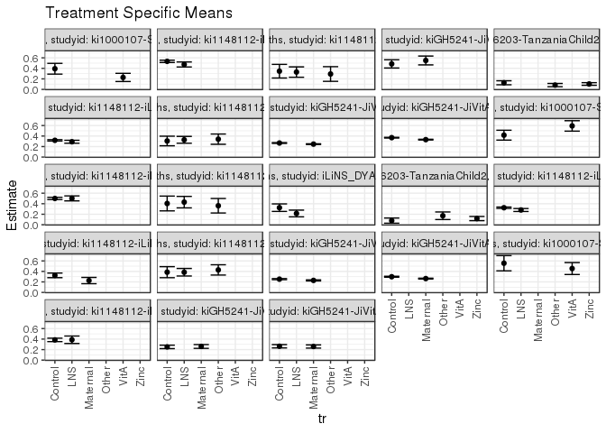

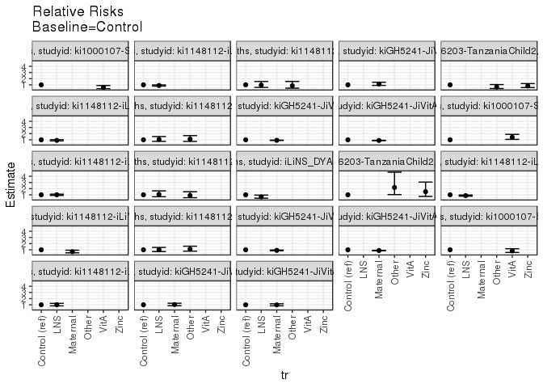

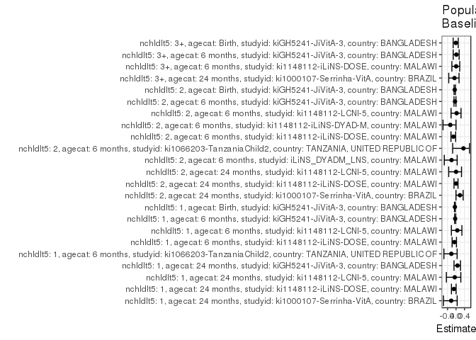

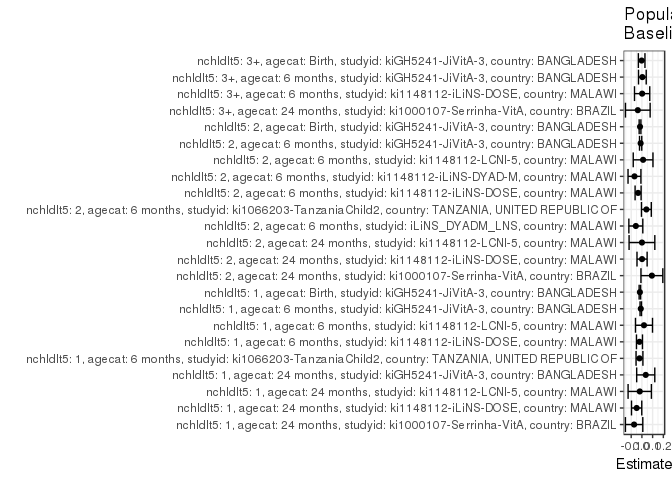

## Results Table

### Parameter: TSM

| nchldlt5 | agecat | studyid | country | intervention_level | baseline_level | estimate | ci_lower | ci_upper |
| --- | --- | --- | --- | --- | --- | --- | --- | --- |
| 1 | Birth | kiGH5241-JiVitA-3 | BANGLADESH | Control | NA | 0.3691130 | 0.3623929 | 0.3758331 |
| 1 | Birth | kiGH5241-JiVitA-3 | BANGLADESH | Maternal | NA | 0.3315833 | 0.3248451 | 0.3383214 |
| 1 | 6 months | ki1066203-TanzaniaChild2 | TANZANIA, UNITED REPUBLIC OF | Control | NA | 0.1258503 | 0.0879206 | 0.1637801 |
| 1 | 6 months | ki1066203-TanzaniaChild2 | TANZANIA, UNITED REPUBLIC OF | Other | NA | 0.0816993 | 0.0509968 | 0.1124019 |
| 1 | 6 months | ki1066203-TanzaniaChild2 | TANZANIA, UNITED REPUBLIC OF | Zinc | NA | 0.1029668 | 0.0780720 | 0.1278617 |
| 1 | 6 months | ki1148112-iLiNS-DOSE | MALAWI | Control | NA | 0.3185185 | 0.3059550 | 0.3310820 |
| 1 | 6 months | ki1148112-iLiNS-DOSE | MALAWI | LNS | NA | 0.2915493 | 0.2634440 | 0.3196546 |
| 1 | 6 months | ki1148112-LCNI-5 | MALAWI | Control | NA | 0.3061224 | 0.2147571 | 0.3974878 |
| 1 | 6 months | ki1148112-LCNI-5 | MALAWI | LNS | NA | 0.3283582 | 0.2633527 | 0.3933637 |
| 1 | 6 months | ki1148112-LCNI-5 | MALAWI | Other | NA | 0.3406593 | 0.2431604 | 0.4381583 |
| 1 | 6 months | kiGH5241-JiVitA-3 | BANGLADESH | Control | NA | 0.2671143 | 0.2598789 | 0.2743498 |
| 1 | 6 months | kiGH5241-JiVitA-3 | BANGLADESH | Maternal | NA | 0.2464032 | 0.2397087 | 0.2530977 |
| 1 | 24 months | ki1000107-Serrinha-VitA | BRAZIL | Control | NA | 0.3928571 | 0.2905262 | 0.4951881 |
| 1 | 24 months | ki1000107-Serrinha-VitA | BRAZIL | VitA | NA | 0.2272727 | 0.1494398 | 0.3051056 |
| 1 | 24 months | ki1148112-iLiNS-DOSE | MALAWI | Control | NA | 0.5333333 | 0.5114747 | 0.5551920 |
| 1 | 24 months | ki1148112-iLiNS-DOSE | MALAWI | LNS | NA | 0.4738676 | 0.4260198 | 0.5217154 |
| 1 | 24 months | ki1148112-LCNI-5 | MALAWI | Control | NA | 0.3461538 | 0.2164891 | 0.4758186 |
| 1 | 24 months | ki1148112-LCNI-5 | MALAWI | LNS | NA | 0.3295455 | 0.2310645 | 0.4280264 |
| 1 | 24 months | ki1148112-LCNI-5 | MALAWI | Other | NA | 0.2926829 | 0.1530252 | 0.4323407 |
| 1 | 24 months | kiGH5241-JiVitA-3 | BANGLADESH | Control | NA | 0.4848485 | 0.4063780 | 0.5633190 |
| 1 | 24 months | kiGH5241-JiVitA-3 | BANGLADESH | Maternal | NA | 0.5500000 | 0.4658907 | 0.6341093 |
| 2 | Birth | kiGH5241-JiVitA-3 | BANGLADESH | Control | NA | 0.2985075 | 0.2898533 | 0.3071616 |
| 2 | Birth | kiGH5241-JiVitA-3 | BANGLADESH | Maternal | NA | 0.2635747 | 0.2556474 | 0.2715020 |
| 2 | 6 months | iLiNS_DYADM_LNS | MALAWI | Control | NA | 0.3250000 | 0.2537603 | 0.3962397 |
| 2 | 6 months | iLiNS_DYADM_LNS | MALAWI | LNS | NA | 0.2142857 | 0.1503340 | 0.2782374 |
| 2 | 6 months | ki1066203-TanzaniaChild2 | TANZANIA, UNITED REPUBLIC OF | Control | NA | 0.0782609 | 0.0291211 | 0.1274006 |
| 2 | 6 months | ki1066203-TanzaniaChild2 | TANZANIA, UNITED REPUBLIC OF | Other | NA | 0.1714286 | 0.0992651 | 0.2435921 |
| 2 | 6 months | ki1066203-TanzaniaChild2 | TANZANIA, UNITED REPUBLIC OF | Zinc | NA | 0.1176471 | 0.0780605 | 0.1572336 |
| 2 | 6 months | ki1148112-iLiNS-DOSE | MALAWI | Control | NA | 0.3239437 | 0.3105244 | 0.3373629 |
| 2 | 6 months | ki1148112-iLiNS-DOSE | MALAWI | LNS | NA | 0.2808321 | 0.2527776 | 0.3088866 |
| 2 | 6 months | ki1148112-iLiNS-DYAD-M | MALAWI | Control | NA | 0.3250000 | 0.2811814 | 0.3688186 |
| 2 | 6 months | ki1148112-iLiNS-DYAD-M | MALAWI | Maternal | NA | 0.2258065 | 0.1661620 | 0.2854509 |
| 2 | 6 months | ki1148112-LCNI-5 | MALAWI | Control | NA | 0.3855422 | 0.2806849 | 0.4903994 |
| 2 | 6 months | ki1148112-LCNI-5 | MALAWI | LNS | NA | 0.3841808 | 0.3124240 | 0.4559376 |
| 2 | 6 months | ki1148112-LCNI-5 | MALAWI | Other | NA | 0.4285714 | 0.3304565 | 0.5266863 |
| 2 | 6 months | kiGH5241-JiVitA-3 | BANGLADESH | Control | NA | 0.2526392 | 0.2426040 | 0.2626745 |
| 2 | 6 months | kiGH5241-JiVitA-3 | BANGLADESH | Maternal | NA | 0.2290623 | 0.2186994 | 0.2394251 |
| 2 | 24 months | ki1000107-Serrinha-VitA | BRAZIL | Control | NA | 0.4166667 | 0.3229242 | 0.5104091 |
| 2 | 24 months | ki1000107-Serrinha-VitA | BRAZIL | VitA | NA | 0.5925926 | 0.4934974 | 0.6916878 |
| 2 | 24 months | ki1148112-iLiNS-DOSE | MALAWI | Control | NA | 0.5000000 | 0.4788259 | 0.5211741 |
| 2 | 24 months | ki1148112-iLiNS-DOSE | MALAWI | LNS | NA | 0.5016722 | 0.4544048 | 0.5489397 |
| 2 | 24 months | ki1148112-LCNI-5 | MALAWI | Control | NA | 0.4042553 | 0.2635482 | 0.5449624 |
| 2 | 24 months | ki1148112-LCNI-5 | MALAWI | LNS | NA | 0.4303797 | 0.3208803 | 0.5398792 |
| 2 | 24 months | ki1148112-LCNI-5 | MALAWI | Other | NA | 0.3617021 | 0.2239351 | 0.4994691 |
| 3+ | Birth | kiGH5241-JiVitA-3 | BANGLADESH | Control | NA | 0.2635983 | 0.2320391 | 0.2951576 |
| 3+ | Birth | kiGH5241-JiVitA-3 | BANGLADESH | Maternal | NA | 0.2587719 | 0.2280553 | 0.2894886 |
| 3+ | 6 months | ki1148112-iLiNS-DOSE | MALAWI | Control | NA | 0.3846154 | 0.3520930 | 0.4171378 |
| 3+ | 6 months | ki1148112-iLiNS-DOSE | MALAWI | LNS | NA | 0.3870968 | 0.3159876 | 0.4582060 |
| 3+ | 6 months | kiGH5241-JiVitA-3 | BANGLADESH | Control | NA | 0.2513661 | 0.2185123 | 0.2842199 |
| 3+ | 6 months | kiGH5241-JiVitA-3 | BANGLADESH | Maternal | NA | 0.2598870 | 0.2239611 | 0.2958129 |
| 3+ | 24 months | ki1000107-Serrinha-VitA | BRAZIL | Control | NA | 0.5555556 | 0.4105519 | 0.7005592 |
| 3+ | 24 months | ki1000107-Serrinha-VitA | BRAZIL | VitA | NA | 0.4545455 | 0.3409570 | 0.5681340 |

### Parameter: E(Y)

| nchldlt5 | agecat | studyid | country | intervention_level | baseline_level | estimate | ci_lower | ci_upper |
| --- | --- | --- | --- | --- | --- | --- | --- | --- |
| 1 | Birth | kiGH5241-JiVitA-3 | BANGLADESH | NA | NA | 0.3502148 | 0.3405588 | 0.3598708 |
| 1 | 6 months | ki1066203-TanzaniaChild2 | TANZANIA, UNITED REPUBLIC OF | NA | NA | 0.1031543 | 0.0857408 | 0.1205678 |
| 1 | 6 months | ki1148112-iLiNS-DOSE | MALAWI | NA | NA | 0.2958580 | 0.2650652 | 0.3266508 |
| 1 | 6 months | ki1148112-LCNI-5 | MALAWI | NA | NA | 0.3256410 | 0.2790729 | 0.3722091 |
| 1 | 6 months | kiGH5241-JiVitA-3 | BANGLADESH | NA | NA | 0.2566347 | 0.2467355 | 0.2665340 |
| 1 | 24 months | ki1000107-Serrinha-VitA | BRAZIL | NA | NA | 0.3200000 | 0.1893891 | 0.4506109 |
| 1 | 24 months | ki1148112-iLiNS-DOSE | MALAWI | NA | NA | 0.4841499 | 0.4314922 | 0.5368075 |
| 1 | 24 months | ki1148112-LCNI-5 | MALAWI | NA | NA | 0.3259669 | 0.2574907 | 0.3944430 |
| 1 | 24 months | kiGH5241-JiVitA-3 | BANGLADESH | NA | NA | 0.5205479 | 0.4052385 | 0.6358574 |
| 2 | Birth | kiGH5241-JiVitA-3 | BANGLADESH | NA | NA | 0.2809117 | 0.2690596 | 0.2927638 |
| 2 | 6 months | iLiNS_DYADM_LNS | MALAWI | NA | NA | 0.2682927 | 0.1718035 | 0.3647819 |
| 2 | 6 months | ki1066203-TanzaniaChild2 | TANZANIA, UNITED REPUBLIC OF | NA | NA | 0.1200000 | 0.0907456 | 0.1492544 |
| 2 | 6 months | ki1148112-iLiNS-DOSE | MALAWI | NA | NA | 0.2883436 | 0.2572245 | 0.3194626 |
| 2 | 6 months | ki1148112-iLiNS-DYAD-M | MALAWI | NA | NA | 0.2556391 | 0.1812231 | 0.3300551 |
| 2 | 6 months | ki1148112-LCNI-5 | MALAWI | NA | NA | 0.3966480 | 0.3459020 | 0.4473941 |
| 2 | 6 months | kiGH5241-JiVitA-3 | BANGLADESH | NA | NA | 0.2407508 | 0.2263142 | 0.2551873 |
| 2 | 24 months | ki1000107-Serrinha-VitA | BRAZIL | NA | NA | 0.5098039 | 0.3712402 | 0.6483677 |
| 2 | 24 months | ki1148112-iLiNS-DOSE | MALAWI | NA | NA | 0.5013928 | 0.4495993 | 0.5531862 |
| 2 | 24 months | ki1148112-LCNI-5 | MALAWI | NA | NA | 0.4046243 | 0.3312734 | 0.4779752 |
| 3+ | Birth | kiGH5241-JiVitA-3 | BANGLADESH | NA | NA | 0.2612420 | 0.2171986 | 0.3052854 |
| 3+ | 6 months | ki1148112-iLiNS-DOSE | MALAWI | NA | NA | 0.3866667 | 0.3084730 | 0.4648603 |
| 3+ | 6 months | kiGH5241-JiVitA-3 | BANGLADESH | NA | NA | 0.2555556 | 0.2068332 | 0.3042779 |
| 3+ | 24 months | ki1000107-Serrinha-VitA | BRAZIL | NA | NA | 0.5172414 | 0.3321523 | 0.7023304 |

### Parameter: RR

| nchldlt5 | agecat | studyid | country | intervention_level | baseline_level | estimate | ci_lower | ci_upper |
| --- | --- | --- | --- | --- | --- | --- | --- | --- |
| 1 | Birth | kiGH5241-JiVitA-3 | BANGLADESH | Control | Control | 1.0000000 | 1.0000000 | 1.0000000 |
| 1 | Birth | kiGH5241-JiVitA-3 | BANGLADESH | Maternal | Control | 0.8983245 | 0.8741360 | 0.9231824 |
| 1 | 6 months | ki1066203-TanzaniaChild2 | TANZANIA, UNITED REPUBLIC OF | Control | Control | 1.0000000 | 1.0000000 | 1.0000000 |
| 1 | 6 months | ki1066203-TanzaniaChild2 | TANZANIA, UNITED REPUBLIC OF | Other | Control | 0.6491786 | 0.4010084 | 1.0509327 |
| 1 | 6 months | ki1066203-TanzaniaChild2 | TANZANIA, UNITED REPUBLIC OF | Zinc | Control | 0.8181690 | 0.5559557 | 1.2040535 |
| 1 | 6 months | ki1148112-iLiNS-DOSE | MALAWI | Control | Control | 1.0000000 | 1.0000000 | 1.0000000 |
| 1 | 6 months | ki1148112-iLiNS-DOSE | MALAWI | LNS | Control | 0.9153292 | 0.8247881 | 1.0158094 |
| 1 | 6 months | ki1148112-LCNI-5 | MALAWI | Control | Control | 1.0000000 | 1.0000000 | 1.0000000 |
| 1 | 6 months | ki1148112-LCNI-5 | MALAWI | LNS | Control | 1.0726368 | 0.7497393 | 1.5345997 |
| 1 | 6 months | ki1148112-LCNI-5 | MALAWI | Other | Control | 1.1128205 | 0.7359340 | 1.6827182 |
| 1 | 6 months | kiGH5241-JiVitA-3 | BANGLADESH | Control | Control | 1.0000000 | 1.0000000 | 1.0000000 |
| 1 | 6 months | kiGH5241-JiVitA-3 | BANGLADESH | Maternal | Control | 0.9224634 | 0.8877431 | 0.9585417 |
| 1 | 24 months | ki1000107-Serrinha-VitA | BRAZIL | Control | Control | 1.0000000 | 1.0000000 | 1.0000000 |
| 1 | 24 months | ki1000107-Serrinha-VitA | BRAZIL | VitA | Control | 0.5785124 | 0.3762264 | 0.8895616 |
| 1 | 24 months | ki1148112-iLiNS-DOSE | MALAWI | Control | Control | 1.0000000 | 1.0000000 | 1.0000000 |
| 1 | 24 months | ki1148112-iLiNS-DOSE | MALAWI | LNS | Control | 0.8885017 | 0.7967673 | 0.9907979 |
| 1 | 24 months | ki1148112-LCNI-5 | MALAWI | Control | Control | 1.0000000 | 1.0000000 | 1.0000000 |
| 1 | 24 months | ki1148112-LCNI-5 | MALAWI | LNS | Control | 0.9520202 | 0.5895736 | 1.5372848 |
| 1 | 24 months | ki1148112-LCNI-5 | MALAWI | Other | Control | 0.8455285 | 0.4609692 | 1.5509028 |
| 1 | 24 months | kiGH5241-JiVitA-3 | BANGLADESH | Control | Control | 1.0000000 | 1.0000000 | 1.0000000 |
| 1 | 24 months | kiGH5241-JiVitA-3 | BANGLADESH | Maternal | Control | 1.1343750 | 0.9079334 | 1.4172918 |
| 2 | Birth | kiGH5241-JiVitA-3 | BANGLADESH | Control | Control | 1.0000000 | 1.0000000 | 1.0000000 |
| 2 | Birth | kiGH5241-JiVitA-3 | BANGLADESH | Maternal | Control | 0.8829751 | 0.8468445 | 0.9206473 |
| 2 | 6 months | iLiNS_DYADM_LNS | MALAWI | Control | Control | 1.0000000 | 1.0000000 | 1.0000000 |
| 2 | 6 months | iLiNS_DYADM_LNS | MALAWI | LNS | Control | 0.6593407 | 0.4552967 | 0.9548282 |
| 2 | 6 months | ki1066203-TanzaniaChild2 | TANZANIA, UNITED REPUBLIC OF | Control | Control | 1.0000000 | 1.0000000 | 1.0000000 |
| 2 | 6 months | ki1066203-TanzaniaChild2 | TANZANIA, UNITED REPUBLIC OF | Other | Control | 2.1904762 | 1.0285718 | 4.6649011 |
| 2 | 6 months | ki1066203-TanzaniaChild2 | TANZANIA, UNITED REPUBLIC OF | Zinc | Control | 1.5032680 | 0.7373202 | 3.0649025 |
| 2 | 6 months | ki1148112-iLiNS-DOSE | MALAWI | Control | Control | 1.0000000 | 1.0000000 | 1.0000000 |
| 2 | 6 months | ki1148112-iLiNS-DOSE | MALAWI | LNS | Control | 0.8669165 | 0.7780544 | 0.9659275 |
| 2 | 6 months | ki1148112-iLiNS-DYAD-M | MALAWI | Control | Control | 1.0000000 | 1.0000000 | 1.0000000 |
| 2 | 6 months | ki1148112-iLiNS-DYAD-M | MALAWI | Maternal | Control | 0.6947891 | 0.5164860 | 0.9346465 |
| 2 | 6 months | ki1148112-LCNI-5 | MALAWI | Control | Control | 1.0000000 | 1.0000000 | 1.0000000 |
| 2 | 6 months | ki1148112-LCNI-5 | MALAWI | LNS | Control | 0.9964689 | 0.7164330 | 1.3859639 |
| 2 | 6 months | ki1148112-LCNI-5 | MALAWI | Other | Control | 1.1116071 | 0.7790393 | 1.5861465 |
| 2 | 6 months | kiGH5241-JiVitA-3 | BANGLADESH | Control | Control | 1.0000000 | 1.0000000 | 1.0000000 |
| 2 | 6 months | kiGH5241-JiVitA-3 | BANGLADESH | Maternal | Control | 0.9066773 | 0.8536965 | 0.9629462 |
| 2 | 24 months | ki1000107-Serrinha-VitA | BRAZIL | Control | Control | 1.0000000 | 1.0000000 | 1.0000000 |
| 2 | 24 months | ki1000107-Serrinha-VitA | BRAZIL | VitA | Control | 1.4222222 | 1.0745464 | 1.8823907 |
| 2 | 24 months | ki1148112-iLiNS-DOSE | MALAWI | Control | Control | 1.0000000 | 1.0000000 | 1.0000000 |
| 2 | 24 months | ki1148112-iLiNS-DOSE | MALAWI | LNS | Control | 1.0033445 | 0.9048732 | 1.1125317 |
| 2 | 24 months | ki1148112-LCNI-5 | MALAWI | Control | Control | 1.0000000 | 1.0000000 | 1.0000000 |
| 2 | 24 months | ki1148112-LCNI-5 | MALAWI | LNS | Control | 1.0646236 | 0.6917585 | 1.6384668 |
| 2 | 24 months | ki1148112-LCNI-5 | MALAWI | Other | Control | 0.8947368 | 0.5340887 | 1.4989159 |
| 3+ | Birth | kiGH5241-JiVitA-3 | BANGLADESH | Control | Control | 1.0000000 | 1.0000000 | 1.0000000 |
| 3+ | Birth | kiGH5241-JiVitA-3 | BANGLADESH | Maternal | Control | 0.9816903 | 0.8293844 | 1.1619653 |
| 3+ | 6 months | ki1148112-iLiNS-DOSE | MALAWI | Control | Control | 1.0000000 | 1.0000000 | 1.0000000 |
| 3+ | 6 months | ki1148112-iLiNS-DOSE | MALAWI | LNS | Control | 1.0064516 | 0.8221807 | 1.2320222 |
| 3+ | 6 months | kiGH5241-JiVitA-3 | BANGLADESH | Control | Control | 1.0000000 | 1.0000000 | 1.0000000 |
| 3+ | 6 months | kiGH5241-JiVitA-3 | BANGLADESH | Maternal | Control | 1.0338983 | 0.8548369 | 1.2504674 |
| 3+ | 24 months | ki1000107-Serrinha-VitA | BRAZIL | Control | Control | 1.0000000 | 1.0000000 | 1.0000000 |
| 3+ | 24 months | ki1000107-Serrinha-VitA | BRAZIL | VitA | Control | 0.8181818 | 0.5700576 | 1.1743050 |

### Parameter: PAR

| nchldlt5 | agecat | studyid | country | intervention_level | baseline_level | estimate | ci_lower | ci_upper |
| --- | --- | --- | --- | --- | --- | --- | --- | --- |
| 1 | Birth | kiGH5241-JiVitA-3 | BANGLADESH | Control | NA | -0.0188982 | -0.0258663 | -0.0119300 |
| 1 | 6 months | ki1066203-TanzaniaChild2 | TANZANIA, UNITED REPUBLIC OF | Control | NA | -0.0226960 | -0.0546448 | 0.0092527 |
| 1 | 6 months | ki1148112-iLiNS-DOSE | MALAWI | Control | NA | -0.0226605 | -0.0507738 | 0.0054527 |
| 1 | 6 months | ki1148112-LCNI-5 | MALAWI | Control | NA | 0.0195186 | -0.0599861 | 0.0990233 |
| 1 | 6 months | kiGH5241-JiVitA-3 | BANGLADESH | Control | NA | -0.0104796 | -0.0172365 | -0.0037227 |
| 1 | 24 months | ki1000107-Serrinha-VitA | BRAZIL | Control | NA | -0.0728571 | -0.1540212 | 0.0083069 |
| 1 | 24 months | ki1148112-iLiNS-DOSE | MALAWI | Control | NA | -0.0491835 | -0.0970899 | -0.0012770 |
| 1 | 24 months | ki1148112-LCNI-5 | MALAWI | Control | NA | -0.0201870 | -0.1290054 | 0.0886314 |
| 1 | 24 months | kiGH5241-JiVitA-3 | BANGLADESH | Control | NA | 0.0356995 | -0.0487858 | 0.1201847 |
| 2 | Birth | kiGH5241-JiVitA-3 | BANGLADESH | Control | NA | -0.0175958 | -0.0257058 | -0.0094857 |
| 2 | 6 months | iLiNS_DYADM_LNS | MALAWI | Control | NA | -0.0567073 | -0.1217847 | 0.0083701 |
| 2 | 6 months | ki1066203-TanzaniaChild2 | TANZANIA, UNITED REPUBLIC OF | Control | NA | 0.0417391 | -0.0041009 | 0.0875791 |
| 2 | 6 months | ki1148112-iLiNS-DOSE | MALAWI | Control | NA | -0.0356001 | -0.0636771 | -0.0075231 |
| 2 | 6 months | ki1148112-iLiNS-DYAD-M | MALAWI | Control | NA | -0.0693609 | -0.1295080 | -0.0092138 |
| 2 | 6 months | ki1148112-LCNI-5 | MALAWI | Control | NA | 0.0111059 | -0.0809373 | 0.1031490 |
| 2 | 6 months | kiGH5241-JiVitA-3 | BANGLADESH | Control | NA | -0.0118885 | -0.0223011 | -0.0014759 |
| 2 | 24 months | ki1000107-Serrinha-VitA | BRAZIL | Control | NA | 0.0931373 | -0.0089032 | 0.1951777 |
| 2 | 24 months | ki1148112-iLiNS-DOSE | MALAWI | Control | NA | 0.0013928 | -0.0458748 | 0.0486603 |
| 2 | 24 months | ki1148112-LCNI-5 | MALAWI | Control | NA | 0.0003690 | -0.1197197 | 0.1204576 |
| 3+ | Birth | kiGH5241-JiVitA-3 | BANGLADESH | Control | NA | -0.0023564 | -0.0330764 | 0.0283637 |
| 3+ | 6 months | ki1148112-iLiNS-DOSE | MALAWI | Control | NA | 0.0020513 | -0.0690581 | 0.0731607 |
| 3+ | 6 months | kiGH5241-JiVitA-3 | BANGLADESH | Control | NA | 0.0041894 | -0.0317602 | 0.0401391 |
| 3+ | 24 months | ki1000107-Serrinha-VitA | BRAZIL | Control | NA | -0.0383142 | -0.1533442 | 0.0767159 |

### Parameter: PAF

| nchldlt5 | agecat | studyid | country | intervention_level | baseline_level | estimate | ci_lower | ci_upper |
| --- | --- | --- | --- | --- | --- | --- | --- | --- |
| 1 | Birth | kiGH5241-JiVitA-3 | BANGLADESH | Control | NA | -0.0539617 | -0.0751629 | -0.0331786 |
| 1 | 6 months | ki1066203-TanzaniaChild2 | TANZANIA, UNITED REPUBLIC OF | Control | NA | -0.2200202 | -0.5705315 | 0.0522639 |
| 1 | 6 months | ki1148112-iLiNS-DOSE | MALAWI | Control | NA | -0.0765926 | -0.1839683 | 0.0210451 |
| 1 | 6 months | ki1148112-LCNI-5 | MALAWI | Control | NA | 0.0599389 | -0.2188285 | 0.2749474 |
| 1 | 6 months | kiGH5241-JiVitA-3 | BANGLADESH | Control | NA | -0.0408348 | -0.0686273 | -0.0137651 |
| 1 | 24 months | ki1000107-Serrinha-VitA | BRAZIL | Control | NA | -0.2276786 | -0.5929756 | 0.0538495 |
| 1 | 24 months | ki1148112-iLiNS-DOSE | MALAWI | Control | NA | -0.1015873 | -0.2162707 | 0.0022825 |
| 1 | 24 months | ki1148112-LCNI-5 | MALAWI | Control | NA | -0.0619296 | -0.4542036 | 0.2245278 |
| 1 | 24 months | kiGH5241-JiVitA-3 | BANGLADESH | Control | NA | 0.0685805 | -0.0959630 | 0.2084201 |
| 2 | Birth | kiGH5241-JiVitA-3 | BANGLADESH | Control | NA | -0.0626381 | -0.0938237 | -0.0323416 |
| 2 | 6 months | iLiNS_DYADM_LNS | MALAWI | Control | NA | -0.2113636 | -0.5506791 | 0.0537037 |
| 2 | 6 months | ki1066203-TanzaniaChild2 | TANZANIA, UNITED REPUBLIC OF | Control | NA | 0.3478261 | -0.1575464 | 0.6325583 |
| 2 | 6 months | ki1148112-iLiNS-DOSE | MALAWI | Control | NA | -0.1234642 | -0.2385293 | -0.0190891 |
| 2 | 6 months | ki1148112-iLiNS-DYAD-M | MALAWI | Control | NA | -0.2713235 | -0.6131144 | -0.0019522 |
| 2 | 6 months | ki1148112-LCNI-5 | MALAWI | Control | NA | 0.0279993 | -0.2341050 | 0.2344369 |
| 2 | 6 months | kiGH5241-JiVitA-3 | BANGLADESH | Control | NA | -0.0493808 | -0.0958044 | -0.0049240 |
| 2 | 24 months | ki1000107-Serrinha-VitA | BRAZIL | Control | NA | 0.1826923 | -0.0025967 | 0.3337382 |
| 2 | 24 months | ki1148112-iLiNS-DOSE | MALAWI | Control | NA | 0.0027778 | -0.0958068 | 0.0924932 |
| 2 | 24 months | ki1148112-LCNI-5 | MALAWI | Control | NA | 0.0009119 | -0.3446706 | 0.2576791 |
| 3+ | Birth | kiGH5241-JiVitA-3 | BANGLADESH | Control | NA | -0.0090198 | -0.1349363 | 0.1029268 |
| 3+ | 6 months | ki1148112-iLiNS-DOSE | MALAWI | Control | NA | 0.0053050 | -0.1955244 | 0.1723983 |
| 3+ | 6 months | kiGH5241-JiVitA-3 | BANGLADESH | Control | NA | 0.0163934 | -0.1321943 | 0.1454807 |
| 3+ | 24 months | ki1000107-Serrinha-VitA | BRAZIL | Control | NA | -0.0740741 | -0.3427090 | 0.1408152 |